# Generalized Linear Regression with `brms`

Vedant Shah

20/06/2020

Use the following data frame:

```r
# set up data frame
dolphin_agg <- dolphin %>%
  filter(correct == 1) %>%
  mutate(straight = as.factor(ifelse(prototype_label == "straight", 1, 0)),
         log_RT_s = scale(log(RT)))
dolphin_agg
```

```
## # A tibble: 1,915 x 18
##       X1 trial_id   MAD     AUC xpos_flips    RT prototype_label subject_id
##    <dbl> <chr>    <dbl>   <dbl>      <dbl> <dbl> <chr>                <dbl>
##  1     1 id0001    82.5  40170.          3   950 straight              1001
##  2     2 id0002    44.7  13947           1  1251 straight              1001
##  3     4 id0004   139.   74084           0   690 curved                1001
##  4     5 id0005   402.  223083           2   951 cCoM                  1001
##  5     6 id0006   670.  308376           2  1079 cCoM                  1001
##  6     7 id0007   850.  281298.          1  1050 dCoM                  1001
##  7     8 id0008    30.8  -2242           0   830 straight              1001
##  8     9 id0009    47.8  16458.          2   700 straight              1001
##  9    10 id0010   -22.6  -2794.          0   810 straight              1001
## 10    11 id0011   423.  182278.          2  1264 cCoM                  1001
## # ... with 1,905 more rows, and 10 more variables: group <chr>,
## #   condition <chr>, exemplar <chr>, category_left <chr>,
## #   category_right <chr>, category_correct <chr>, response <chr>,
## #   correct <dbl>, straight <fct>, log_RT_s[,1] <dbl>
```

## Exercise 2 *HOMEWORK*

### (a) (10 points)

We will continue to use `dolphin_agg` in this exercise. Plot the relationship between `xpos_flips` and `log_RT_s` in a scatterplot and visually differentiate between `condition`s as you see fit.

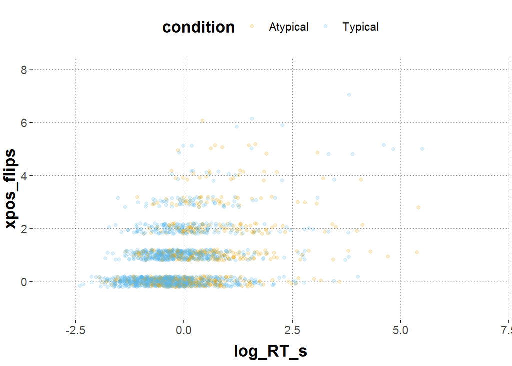

```r
ggplot(data = dolphin_agg) +
  geom_point(aes(x = log_RT_s, y = xpos_flips, colour = condition),
             # we add a little bit of jitter to make the points better visible
             position = position_jitter(height = 0.2), alpha = 0.2) +
  ylim(-1,8) +
  xlim(-3,7)
```

### (b) (10 points)

Run an appropriate generalized regression model for xflips with `brms` to predict `xpos_flips` based on `log_RT_s`, `condition`, and their two-way interaction.

```r
model1 <- brm(xpos_flips ~ log_RT_s*condition,
                 dolphin_agg, cores = 4,
              family = "poisson")
model1
```

```
##  Family: poisson
##   Links: mu = log
## Formula: xpos_flips ~ log_RT_s * condition
##    Data: dolphin_agg (Number of observations: 1915)
## Samples: 4 chains, each with iter = 2000; warmup = 1000; thin = 1;
##          total post-warmup samples = 4000
##
## Population-Level Effects:
##                           Estimate Est.Error l-95% CI u-95% CI Rhat
## Intercept                    -0.09      0.05    -0.18    -0.01 1.00
## log_RT_s                      0.26      0.03     0.20     0.32 1.00
## conditionTypical             -0.18      0.06    -0.29    -0.07 1.00
## log_RT_s:conditionTypical     0.10      0.04     0.02     0.18 1.00
##                           Bulk_ESS Tail_ESS
## Intercept                     2252     2454
## log_RT_s                      1766     2280
## conditionTypical              2088     2557
## log_RT_s:conditionTypical     1912     2067
##
## Samples were drawn using sampling(NUTS). For each parameter, Bulk_ESS
## and Tail_ESS are effective sample size measures, and Rhat is the potential
## scale reduction factor on split chains (at convergence, Rhat = 1).
```

### (c) (25 points)

Extract the posterior means and 95% CrIs across a range of representative values of log_RT_s (see walkthrough) for both conditions and plot them against the data (as done before in walkthrough and exercise 1).

```r
predicted_values <- model1 %>%
  spread_draws(b_Intercept, b_log_RT_s, b_conditionTypical, `b_log_RT_s:conditionTypical`) %>%
  # make a list of relevant value range of logRT
  mutate(log_RT = list(seq(-3, 5, 0.2))) %>%
  unnest(log_RT) %>%
  # transform into proportion space
  mutate(pred_Atypical = exp(b_Intercept + b_log_RT_s * log_RT),
         pred_Typical = exp(b_Intercept + b_log_RT_s * log_RT +
                               b_conditionTypical + `b_log_RT_s:conditionTypical` * log_RT)
         ) %>%
  group_by(log_RT) %>%
  summarise(Atypical_mean = mean(pred_Atypical, na.rm = TRUE),
            Atypical_low = quantile(pred_Atypical, prob = 0.025),
            Atypical_high = quantile(pred_Atypical, prob = 0.975),
            Typical_mean = mean(pred_Typical, na.rm = TRUE),
            Typical_low = quantile(pred_Typical, prob = 0.025),
            Typical_high = quantile(pred_Typical, prob = 0.975)
            )

predicted_values
```

```
## # A tibble: 41 x 7
##    log_RT Atypical_mean Atypical_low Atypical_high Typical_mean Typical_low
##     <dbl>         <dbl>        <dbl>         <dbl>        <dbl>       <dbl>
##  1  -3            0.422        0.330         0.538        0.260       0.220
##  2  -2.8          0.444        0.352         0.560        0.279       0.238
##  3  -2.6          0.468        0.374         0.582        0.300       0.258
##  4  -2.4          0.492        0.398         0.606        0.322       0.279
##  5  -2.2          0.518        0.424         0.631        0.346       0.302
##  6  -2            0.545        0.452         0.656        0.371       0.328
##  7  -1.8          0.574        0.481         0.682        0.399       0.355
##  8  -1.60         0.604        0.512         0.711        0.428       0.384
##  9  -1.4          0.636        0.545         0.741        0.460       0.416
## 10  -1.2          0.669        0.580         0.772        0.494       0.450
## # ... with 31 more rows, and 1 more variable: Typical_high <dbl>
```

[figure not shown]

```r
ggplot(data = predicted_values) +
  geom_point(data = dolphin_agg,
             aes(x = log_RT_s, y = xpos_flips, color = condition),
             position = position_jitter(height = 0.02), alpha = 0.2) +
  geom_ribbon(aes(x = log_RT, ymin = Atypical_low, ymax = Atypical_high), alpha = 0.2) +
  geom_ribbon(aes(x = log_RT, ymin = Typical_low, ymax = Typical_high), alpha = 0.2) +
  geom_line(aes(x = log_RT, y = Atypical_mean), color = "#E69F00", size = 2) +
  geom_line(aes(x = log_RT, y = Typical_mean), color = "#56B4E9", size = 2) +
  ylab("Predicted prob of straight trajectory")
```

### Bonus

Binary logistic regression assumes that the outcome variable comes from a Bernoulli distribution which is a special case of a binomial distribution where the number of trial $n = 1$ and thus the outcome variable can only be 1 or 0. In contrast, binomial logistic regression assumes that the number of the target events follows a binomial distribution with $n$ trials and probability $q$. Read up on Binomial data with `brms` here: https://www.rensvandeschoot.com/tutorials/generalised-linear-models-with-brms/

Take the following subset of the `dolphin` data frame that only contains `correct` responses (= `1`).

```r
# set up data frame
dolphin_sub <- dolphin %>%
  filter(correct == 1) %>%
  mutate(straight = (ifelse(prototype_label == "straight", 1, 0)),
         log_RT_s = scale(log(RT)))
dolphin_sub
```

```
## # A tibble: 1,915 x 18
##       X1 trial_id   MAD     AUC xpos_flips    RT prototype_label subject_id
##    <dbl> <chr>    <dbl>   <dbl>      <dbl> <dbl> <chr>                <dbl>
##  1     1 id0001    82.5  40170.          3   950 straight              1001
##  2     2 id0002    44.7  13947           1  1251 straight              1001
##  3     4 id0004   139.   74084           0   690 curved                1001
##  4     5 id0005   402.  223083           2   951 cCoM                  1001
##  5     6 id0006   670.  308376           2  1079 cCoM                  1001
##  6     7 id0007   850.  281298.          1  1050 dCoM                  1001
##  7     8 id0008    30.8  -2242           0   830 straight              1001
##  8     9 id0009    47.8  16458.          2   700 straight              1001
##  9    10 id0010   -22.6  -2794.          0   810 straight              1001
## 10    11 id0011   423.  182278.          2  1264 cCoM                  1001
## # ... with 1,905 more rows, and 10 more variables: group <chr>,
## #   condition <chr>, exemplar <chr>, category_left <chr>,
## #   category_right <chr>, category_correct <chr>, response <chr>,
## #   correct <dbl>, straight <dbl>, log_RT_s[,1] <dbl>
```

### Bonus (a)

For each `subject_id` in each `group`, aggregate the mean log_RT_s, the number of trials that are classified as `straight` trajectories, and the total number of trials. Plot the proportion of trials that are classified as `straight` (vs. all trials) trajectories for each subject.

```r
mean_log <- dolphin_sub %>% group_by(subject_id, group) %>% summarise(mean_log = mean(log_RT_s), total_trials = n())
count <- dolphin_sub %>% group_by(subject_id, group) %>% filter(straight == 1) %>% summarise(straight_trials = n())
data <- full_join(mean_log, count, by = c("subject_id", "group"))
#data <- data %>% mutate(prop = straight_trials/total_trials)
data
```

```
## # A tibble: 108 x 5
## # Groups:   subject_id [108]
##    subject_id group mean_log total_trials straight_trials
##         <dbl> <chr>    <dbl>        <int>           <int>
##  1       1001 touch   -1.16            16               8
##  2       1002 click   -0.130           19              11
##  3       1003 click    1.38            17              16
##  4       1004 touch   -0.144           18              13
##  5       1005 touch   -0.423           17               9
##  6       1006 touch   -0.464           19              10
##  7       1007 click    0.308           19              11
##  8       1008 touch   -0.627           18              18
##  9       1009 touch    0.894           19              17
## 10       1010 click   -0.379           19               9
## # ... with 98 more rows
```

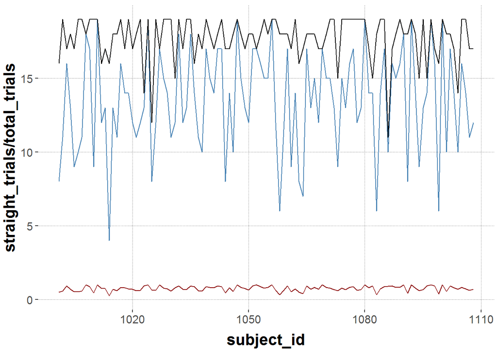

```r
ggplot(data) +
    geom_line(aes(y=straight_trials/total_trials, x=subject_id), colour = "darkred") + geom_line(aes(y=straight_trials, x=subject_id), colour = "steelblue") + geom_line(aes(y=total_trials, x=subject_id), colour = "black") + scale_color_manual(name = "Labels", labels = c("darkred"= "Proportion", "steelblue"="Total Straight","black"= "Total Trajectories"))
```